# Week 2, day 1

**HW2: Data Visualization**  
Hao-Chien Wang

**Some variables**

- `n`: number of times a word is used in a source of text.
- `n_shift`: normalized `n`. Since the numbers of words in total from different sources are different, it must be normalized.
- `exNum`: Number of sentence examples provided by `dictionary.com`

I use the words collected (with [crawlers](https://fhcwcsy.github.io/data_science_programming/week_1/day2/dictionary/dictionary_project.html)) from three of the largest forums in `stackexchange` (*arqade*, *askubuntu* and *English grammar & usage*) and look up those words in `dictionary.com` and count the number of example sentences using the crawler. First, I load the data and try to plot some simple graph:

```r
library(dplyr)
#English
data_eng = read.csv("~/Documents/summerproj/data_science_programming/week_1/day2/dictionary/dictionary_com_output_english_20000.csv", header = TRUE )
data_eng = filter(data_eng, exNum >= 0)
data_eng$n_shift = ( (data_eng$n - mean(data_eng$n) ) / sd(data_eng$n) ) * 0.2 + 1
data_eng$n = ( (data_eng$n - mean(data_eng$n) ) / sd(data_eng$n) )
data_eng$word_source = "english"
#arqade
data_arqade = read.csv("~/Documents/summerproj/data_science_programming/week_1/day2/dictionary/dictionary_com_output_gaming.csv", header = TRUE )
data_arqade = filter(data_arqade, exNum >= 0)
data_arqade$n_shift = ( (data_arqade$n - mean(data_arqade$n) ) / sd(data_arqade$n) ) * 0.2 + 1
data_arqade$n = ( (data_arqade$n - mean(data_arqade$n) ) / sd(data_arqade$n) )
data_arqade$word_source = "arqade"
#askubuntu
data_ubuntu = read.csv("~/Documents/summerproj/data_science_programming/week_1/day2/dictionary/dictionary_com_output_askubuntu.csv", header = TRUE )
data_ubuntu = filter(data_ubuntu, exNum >= 0)
data_ubuntu$n_shift = ( (data_ubuntu$n - mean(data_ubuntu$n) ) / sd(data_ubuntu$n) ) * 0.2 + 1
data_ubuntu$n = ( (data_ubuntu$n - mean(data_ubuntu$n) ) / sd(data_ubuntu$n) )
data_ubuntu$word_source = "askubuntu"
#combine
data = rbind(data_ubuntu, data_eng, data_arqade)
head(data)
```

```
##   X word         n exNum  n_shift word_source
## 1 1  the 137.63091    18 28.52618   askubuntu
## 2 2   to  88.42767    24 18.68553   askubuntu
## 3 3  and  53.62696    18 11.72539   askubuntu
## 4 4    a  52.40956    34 11.48191   askubuntu
## 5 5    i  51.77989     2 11.35598   askubuntu
## 6 6  you  47.04576     8 10.40915   askubuntu
```

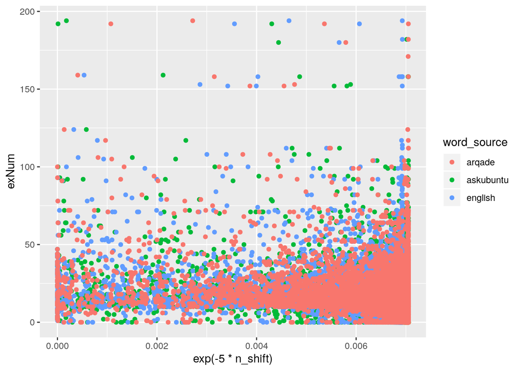

```r
#plot
library(ggplot2)
ggplot(data, aes( x = exp( - 5 * n_shift ), y = exNum, color = word_source)) + geom_point()
```

I use `e^{-5 \times n\_shift}` as the x-axis to rescale `n` so I can have a better view. It can be noticed that there’s a horizontal line, while most of the dots are above the line, which means most of the words have at least some numbers of examples. I want to find that line, so I plot the count of different `exNum`:

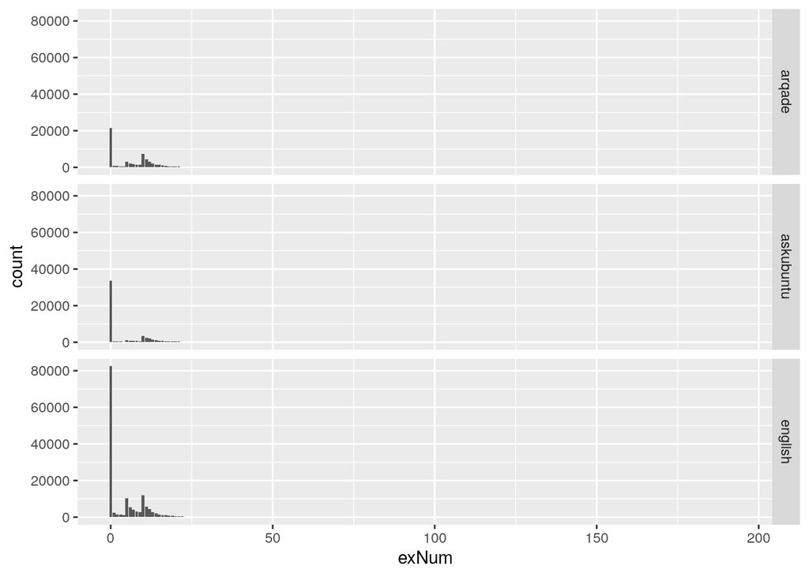

```r
ggplot(data, aes( x = exNum, )) + geom_bar() + facet_grid(word_source ~ .)
```

The result is not so satisfying because the number of words with `exNum = 0` is overwhelmingly large. I print them out to find the reason:

```r
head(filter(data, exNum == 0, word_source == "askubuntu"), n = 20)
```

```
##       X      word         n exNum  n_shift word_source
## 1   118   doesn't 3.1174005     0 1.623480   askubuntu
## 2   151      i've 2.4134422     0 1.482688   askubuntu
## 3   212      http 1.7429120     0 1.348582   askubuntu
## 4   226      ctrl 1.6660053     0 1.333201   askubuntu
## 5   228     can't 1.6504929     0 1.330099   askubuntu
## 6   245    didn't 1.5049819     0 1.300996   askubuntu
## 7   358     isn't 0.9884836     0 1.197697   askubuntu
## 8   439       i'd 0.7730575     0 1.154611   askubuntu
## 9   499       usr 0.6620671     0 1.132413   askubuntu
## 10  532      i'll 0.6190256     0 1.123805   askubuntu
## 11  537       cpu 0.6124711     0 1.122494   askubuntu
## 12  713   haven't 0.4121204     0 1.082424   askubuntu
## 13  820  releases 0.3354322     0 1.067086   askubuntu
## 14  856      unix 0.3177349     0 1.063547   askubuntu
## 15  860  couldn't 0.3166425     0 1.063329   askubuntu
## 16  905       php 0.2917352     0 1.058347   askubuntu
## 17  926 uninstall 0.2827773     0 1.056555   askubuntu
## 18  959    wasn't 0.2670464     0 1.053409   askubuntu
## 19  996       hdd 0.2519710     0 1.050394   askubuntu
## 20 1075 shouldn't 0.2216016     0 1.044320   askubuntu
```

```r
head(filter(data, exNum == 0, word_source == "english"), n = 20)
```

```
##       X      word         n exNum  n_shift word_source
## 1   131   doesn't 4.0350277     0 1.807006     english
## 2   151      i've 3.3936282     0 1.678726     english
## 3   200     can't 2.3939633     0 1.478793     english
## 4   212       i'd 2.2550629     0 1.451013     english
## 5   213     isn't 2.2529760     0 1.450595     english
## 6   309    didn't 1.5605613     0 1.312112     english
## 7   443      i'll 1.0369605     0 1.207392     english
## 8   455      http 0.9831627     0 1.196633     english
## 9   464   they're 0.9588145     0 1.191763     english
## 10  756    wasn't 0.5697081     0 1.113942     english
## 11  858   haven't 0.4885477     0 1.097710     english
## 12  878  couldn't 0.4713880     0 1.094278     english
## 13 1294 shouldn't 0.2842552     0 1.056851     english
## 14 1365       pre 0.2698782     0 1.053976     english
## 15 1457 webster's 0.2478490     0 1.049570     english
## 16 1529       ing 0.2337039     0 1.046741     english
## 17 1620        cf 0.2156167     0 1.043123     english
## 18 1935       odo 0.1694712     0 1.033894     english
## 19 2043  downvote 0.1560217     0 1.031204     english
## 20 2175    hasn't 0.1434998     0 1.028700     english
```

```r
head(filter(data, exNum == 0, word_source == "arqade"), n = 20)
```

```
##       X      word         n exNum  n_shift word_source
## 1    81      i've 3.9459622     0 1.789192      arqade
## 2   121     can't 2.6753765     0 1.535075      arqade
## 3   123   doesn't 2.6277880     0 1.525558      arqade
## 4   229    didn't 1.4474279     0 1.289486      arqade
## 5   263     isn't 1.2771546     0 1.255431      arqade
## 6   301       i'd 1.1085317     0 1.221706      arqade
## 7   333   haven't 0.9679668     0 1.193593      arqade
## 8   338 minecraft 0.9533877     0 1.190678      arqade
## 9   344      i'll 0.9393587     0 1.187872      arqade
## 10  373   they're 0.8571103     0 1.171422      arqade
## 11  517      http 0.5993622     0 1.119872      arqade
## 12  795       dps 0.3614196     0 1.072284      arqade
## 13  806    wasn't 0.3556430     0 1.071129      arqade
## 14  915  couldn't 0.2995271     0 1.059905      arqade
## 15 1163       pre 0.2205796     0 1.044116      arqade
## 16 1173 shouldn't 0.2183790     0 1.043676      arqade
## 17 1180   they'll 0.2172787     0 1.043456      arqade
## 18 1239  cooldown 0.2065507     0 1.041310      arqade
## 19 1358     it'll 0.1823438     0 1.036469      arqade
## 20 1361       civ 0.1817936     0 1.036359      arqade
```

As we can see, there are several cases in the words with `exNum = 0`:

- common english words that doesn’t have a dictionary page, *e.g. doesn’t, isn’t*.
- words in the original html files that was not filtered out during the crawling process, *e.g. http, www*.
- words related to specific data source, e.g. mincraft(arqade), usr(askubuntu), unix(askubuntu)

Since we seldom look up those kinds of words in the dictionary, I filtered them out and plot again:

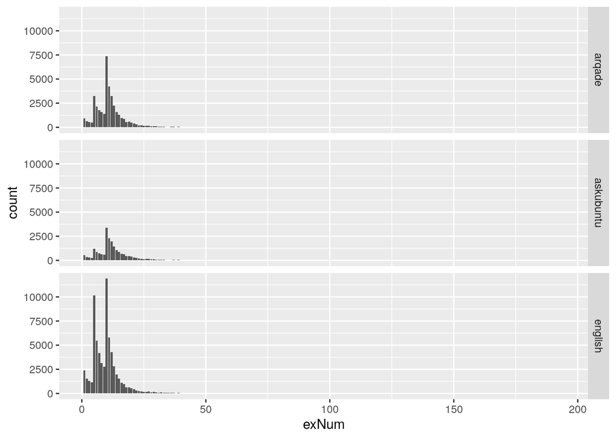

```r
data = filter(data, exNum != 0)
ggplot(data, aes( x = exNum, )) + geom_bar() + facet_grid(word_source ~ .)
```

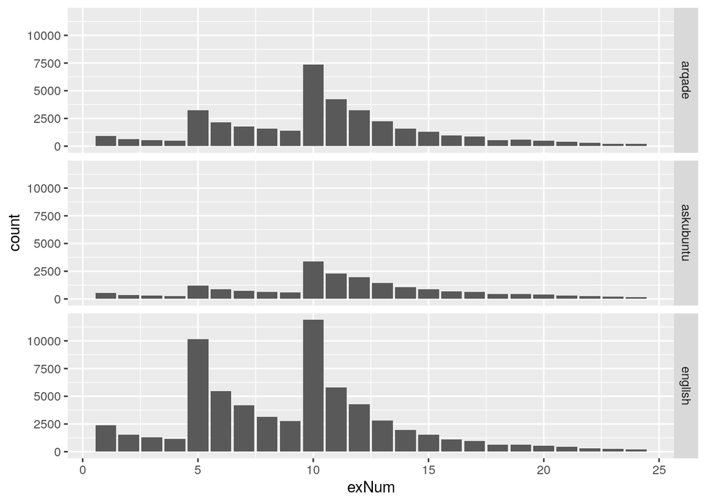

```r
#zoom in at smaller exNum
ggplot(filter(data,exNum < 25), aes( x = exNum)) + geom_bar() + facet_grid(word_source ~ .)
```

Here, we can see the difference between different data sources. Most words in `askubuntu` and `arqade` have at least 10 examples, while there is a number of words in the `english` forum that have 5 ~ 10 examples. However, this doesn’t necessarily means that users in the `english` forum use words that are more rarely used, as shown in the next part.

Lastly, I examine the the behavior of `exNum` when `n` become small, since we normally look up the dictionary for less used words. I calculate the count of words which `exNum < 5`.

```r
#use new data from the English forum in stackexchange since I want all n to be positive and unscaled again
data_new = read.csv("~/Documents/summerproj/data_science_programming/week_1/day2/dictionary/dictionary_com_output_english_20000.csv", header = TRUE )
data_new = filter(data_new, exNum > 0)

#rescale n
data_new$log_n = floor(log(data_new$n)/0.3)*0.3

#head(arrange(select( data_new,exNum , n_cut, exNum, word), n_cut, word) , n = 100)

#count the number of data which has less than 5 examples
data_n = filter( data_new, exNum < 5 ) %>%
  count( log_n, sort=TRUE )

#count the total number of data
data_n_total = data_new %>%
  count( log_n, sort=TRUE )

#calculate the ratio. The higher the ratio is, the more words with this value of n have less than 5 examples
n_ratio = merge(data_n, data_n_total, by = "log_n")
n_ratio$ratio = n_ratio$n.x / n_ratio$n.y
head(n_ratio, n = 20)
```

```
##    log_n  n.x  n.y       ratio
## 1    0.0  370 1592 0.232412060
## 2    0.6 1690 9606 0.175931709
## 3    0.9  946 5997 0.157745539
## 4    1.2  597 4424 0.134945750
## 5    1.5  717 6199 0.115663817
## 6    1.8  410 4254 0.096379878
## 7    2.1  386 4399 0.087747215
## 8    2.4  254 3233 0.078564800
## 9    2.7  269 4475 0.060111732
## 10   3.0  197 3493 0.056398511
## 11   3.3  134 3003 0.044622045
## 12   3.6  102 2884 0.035367545
## 13   3.9   62 2318 0.026747196
## 14   4.2   62 2059 0.030111705
## 15   4.5   45 1696 0.026533019
## 16   4.8   24 1432 0.016759777
## 17   5.1   19 1203 0.015793849
## 18   5.4   12 1001 0.011988012
## 19   5.7    7  773 0.009055627
## 20   6.0    9  676 0.013313609
```

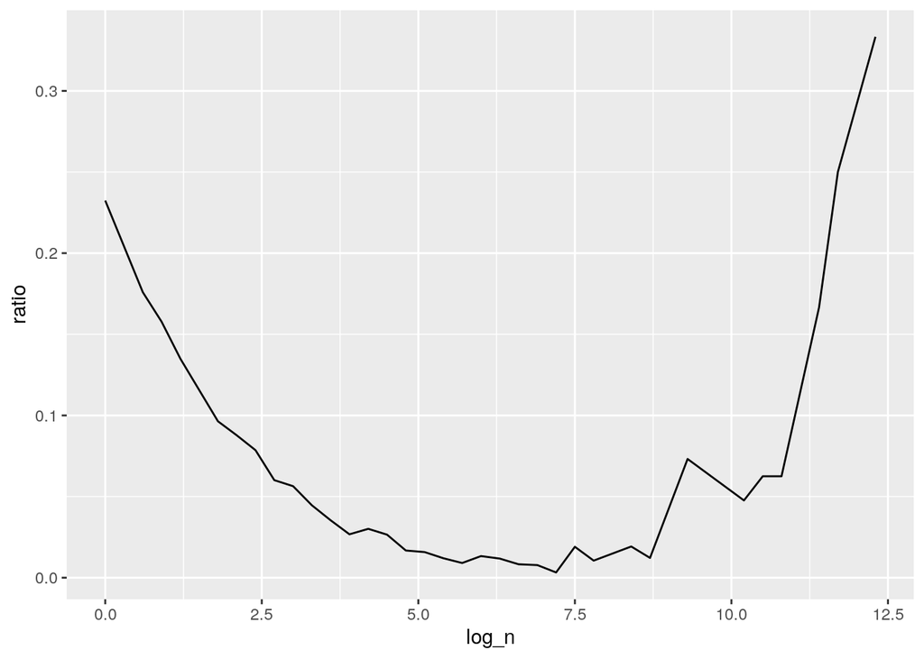

```r
#plot
ggplot(n_ratio, aes( x = log_n, y = ratio)) + geom_line()
```

The ratio is larger when n is either very large or very small, which indicates that when a word is commonly used or very rarely used, there is a larger chance that you will find fewer examples in `dictionary.com`. Therefore, we can conclude that the dictionary has attempted to add more examples to the words that are not so commonly used, but it is still difficult to find examples for those rare words.